# SM_01_SEC_STCK_NUM_CONTR

Securities - closely held stock - number of contributions or items contributed · Number report

## Overview

**Description**

Number of contributions

**Table**

`SM-P01-T00-NONCASH-CONTRIBUTIONS` (one)

**Location code**

`SCHED-M-PART-01-LINE-10-COL-B`

**Family**

`SCHED-M-PART-01-LINE-10-COL-B`

**Data type**

numeric (xsd: , IntegerNNType)

**Scope**

PC

**Status**

unreviewed

3

xpaths mapped (2 observed)

2,806

filings with a value

2009–2024

tax years observed

1

open flags (0 errors)

## Flags

| Severity | Flag | Xpath | Detail |
| --- | --- | --- | --- |
| ⓘ info | `UNOBSERVED` | IRS990ScheduleM/Form990ScheduleMPartI/SecuritiesCloselyHeldStock/NumberOfContributions | never observed in TY2009-2024 filings |

## Xpaths

All mapped xpaths (under /Return/ReturnData or /Return/ReturnHeader), oldest first. Charts label each series by its xpath.

| Xpath | Form | Chart label | First year | Last year | Versions | Filings | Repeats in |
| --- | --- | --- | --- | --- | --- | --- | --- |
| IRS990ScheduleM/SecuritiesCloselyHeldStock/NumberOfContributions | Sched M | …cheduleM/SecuritiesCloselyHeldStock/NumberOfContributions | 2009 | 2012 | 15 | 574 | 0.0% |
| IRS990ScheduleM/SecuritiesCloselyHeldStockGrp/ContributionCnt | Sched M | …90ScheduleM/SecuritiesCloselyHeldStockGrp/ContributionCnt | 2013 | 2024 | 36 | 2,232 | 0.0% |
| IRS990ScheduleM/Form990ScheduleMPartI/SecuritiesCloselyHeldStock/NumberOfContributions | Sched M | …leMPartI/SecuritiesCloselyHeldStock/NumberOfContributions |  |  |  | 0 |  |

## Coverage

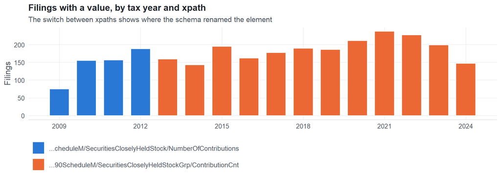

**Table view**

Table view: filings by tax year and series

| Tax year | …cheduleM/SecuritiesCloselyHeldStock/NumberOfContributions | …90ScheduleM/SecuritiesCloselyHeldStockGrp/ContributionCnt |
| --- | --- | --- |
| 2009 | 75 | 0 |
| 2010 | 155 | 0 |
| 2011 | 156 | 0 |
| 2012 | 188 | 0 |
| 2013 | 0 | 159 |
| 2014 | 0 | 143 |
| 2015 | 0 | 195 |
| 2016 | 0 | 162 |
| 2017 | 0 | 177 |
| 2018 | 0 | 189 |
| 2019 | 0 | 186 |
| 2020 | 0 | 211 |
| 2021 | 0 | 237 |
| 2022 | 0 | 227 |
| 2023 | 0 | 199 |
| 2024 | 0 | 147 |

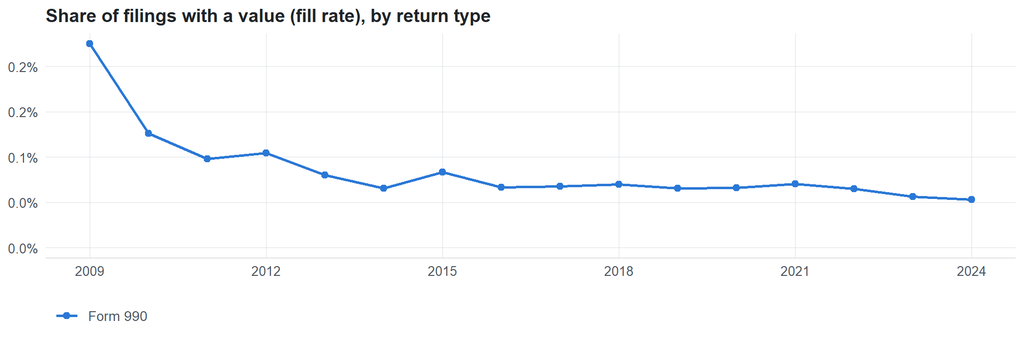

**Table view**

Table view: fill rate

| Tax year | Return type | Filings | All filings | Fill rate |
| --- | --- | --- | --- | --- |
| 2009 | Form 990 | 75 | 33,311 | 0.23% |
| 2010 | Form 990 | 155 | 123,025 | 0.13% |
| 2011 | Form 990 | 156 | 159,504 | 0.10% |
| 2012 | Form 990 | 188 | 179,688 | 0.10% |
| 2013 | Form 990 | 159 | 198,855 | 0.08% |
| 2014 | Form 990 | 143 | 218,619 | 0.07% |
| 2015 | Form 990 | 195 | 233,519 | 0.08% |
| 2016 | Form 990 | 162 | 243,903 | 0.07% |
| 2017 | Form 990 | 177 | 261,612 | 0.07% |
| 2018 | Form 990 | 189 | 271,442 | 0.07% |
| 2019 | Form 990 | 186 | 283,694 | 0.07% |
| 2020 | Form 990 | 211 | 320,342 | 0.07% |
| 2021 | Form 990 | 237 | 336,480 | 0.07% |
| 2022 | Form 990 | 227 | 349,055 | 0.07% |
| 2023 | Form 990 | 199 | 354,768 | 0.06% |
| 2024 | Form 990 | 147 | 277,298 | 0.05% |

## Values

| Result | Check | Detail |
| --- | --- | --- |
| ✓ pass | Values parse as numbers | 100.0% of values are numeric |
| ✓ pass | Pooled xpaths are on the same scale (same return type) | largest ratio of medians between xpaths: 1.8x |
| ⚠ fail | One scale across xpaths (fraction vs percent) | …cheduleM/SecuritiesCloselyHeldStock/NumberOfContributions: percent or small count; …90ScheduleM/SecuritiesCloselyHeldStockGrp/ContributionCnt: large count or amount |

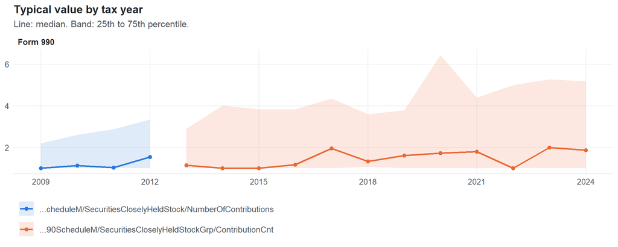

**Table view**

Table view: quartiles by tax year

| Series | Return | Tax year | Filings | P25 | Median | P75 |
| --- | --- | --- | --- | --- | --- | --- |
| …cheduleM/SecuritiesCloselyHeldStock/NumberOfContributions | 990 | 2009 | 75 | 1 | 1 | 2.20 |
| …cheduleM/SecuritiesCloselyHeldStock/NumberOfContributions | 990 | 2010 | 155 | 1 | 1.14 | 2.61 |
| …cheduleM/SecuritiesCloselyHeldStock/NumberOfContributions | 990 | 2011 | 156 | 1.03 | 1.03 | 2.88 |
| …cheduleM/SecuritiesCloselyHeldStock/NumberOfContributions | 990 | 2012 | 188 | 1 | 1.54 | 3.34 |
| …90ScheduleM/SecuritiesCloselyHeldStockGrp/ContributionCnt | 990 | 2013 | 159 | 1 | 1.14 | 2.89 |
| …90ScheduleM/SecuritiesCloselyHeldStockGrp/ContributionCnt | 990 | 2014 | 143 | 1 | 1 | 4.01 |
| …90ScheduleM/SecuritiesCloselyHeldStockGrp/ContributionCnt | 990 | 2015 | 195 | 1 | 1 | 3.85 |
| …90ScheduleM/SecuritiesCloselyHeldStockGrp/ContributionCnt | 990 | 2016 | 162 | 1 | 1.18 | 3.82 |
| …90ScheduleM/SecuritiesCloselyHeldStockGrp/ContributionCnt | 990 | 2017 | 177 | 1 | 1.95 | 4.36 |
| …90ScheduleM/SecuritiesCloselyHeldStockGrp/ContributionCnt | 990 | 2018 | 189 | 1.08 | 1.33 | 3.60 |
| …90ScheduleM/SecuritiesCloselyHeldStockGrp/ContributionCnt | 990 | 2019 | 186 | 1 | 1.62 | 3.79 |
| …90ScheduleM/SecuritiesCloselyHeldStockGrp/ContributionCnt | 990 | 2020 | 211 | 1 | 1.73 | 6.44 |
| …90ScheduleM/SecuritiesCloselyHeldStockGrp/ContributionCnt | 990 | 2021 | 237 | 1 | 1.80 | 4.39 |
| …90ScheduleM/SecuritiesCloselyHeldStockGrp/ContributionCnt | 990 | 2022 | 227 | 1 | 1 | 4.98 |
| …90ScheduleM/SecuritiesCloselyHeldStockGrp/ContributionCnt | 990 | 2023 | 199 | 1 | 1.99 | 5.27 |
| …90ScheduleM/SecuritiesCloselyHeldStockGrp/ContributionCnt | 990 | 2024 | 147 | 1 | 1.87 | 5.18 |

Summary by xpath and return type (all years)

| Series | Return | Filings | % numeric | % zero | % negative | Median (typical year) | P99 (typical year) |
| --- | --- | --- | --- | --- | --- | --- | --- |
| …cheduleM/SecuritiesCloselyHeldStock/NumberOfContributions | 990 | 574 | 100 | 0.52 | 0 | 1 | 20 |
| …90ScheduleM/SecuritiesCloselyHeldStockGrp/ContributionCnt | 990 | 2,232 | 100 | 0.67 | 0 | 1 | 2191 |

Scale of each xpath

| Series | P99 (typical year) | Implied scale |
| --- | --- | --- |
| …cheduleM/SecuritiesCloselyHeldStock/NumberOfContributions | 20 | percent or small count |
| …90ScheduleM/SecuritiesCloselyHeldStockGrp/ContributionCnt | 2191 | large count or amount |

## Examples

| Tax year | Return | Xpath | Organization | Value | Source |
| --- | --- | --- | --- | --- | --- |
| 2024 | 990 | IRS990ScheduleM/SecuritiesCloselyHeldStockGrp/ContributionCnt | WEBSTER HOUSE | 1 | [XML](https://gt990datalake-rawdata.s3.amazonaws.com/EfileData/XmlFiles/202532119349301613_public.xml) |
| 2023 | 990 | IRS990ScheduleM/SecuritiesCloselyHeldStockGrp/ContributionCnt | DONOR ADVISED CHARITABLE GIVING INC | 12 | [XML](https://gt990datalake-rawdata.s3.amazonaws.com/EfileData/XmlFiles/202541069349300729_public.xml) |
| 2022 | 990 | IRS990ScheduleM/SecuritiesCloselyHeldStockGrp/ContributionCnt | THE ROBERT F WOLFE & EDGAR T WOLFE | 2 | [XML](https://gt990datalake-rawdata.s3.amazonaws.com/EfileData/XmlFiles/202323139349304627_public.xml) |
| 2021 | 990 | IRS990ScheduleM/SecuritiesCloselyHeldStockGrp/ContributionCnt | AIP Foundation | 3 | [XML](https://gt990datalake-rawdata.s3.amazonaws.com/EfileData/XmlFiles/202212719349300021_public.xml) |
| 2020 | 990 | IRS990ScheduleM/SecuritiesCloselyHeldStockGrp/ContributionCnt | ST JOHN’S UNIVERSITY NEW YORK | 1 | [XML](https://gt990datalake-rawdata.s3.amazonaws.com/EfileData/XmlFiles/202230989349301408_public.xml) |
| 2019 | 990 | IRS990ScheduleM/SecuritiesCloselyHeldStockGrp/ContributionCnt | BRADLEY IMPACT FUND INC | 1 | [XML](https://gt990datalake-rawdata.s3.amazonaws.com/EfileData/XmlFiles/202022979349301842_public.xml) |
| 2018 | 990 | IRS990ScheduleM/SecuritiesCloselyHeldStockGrp/ContributionCnt | ENDURING HEARTS INC | 11 | [XML](https://gt990datalake-rawdata.s3.amazonaws.com/EfileData/XmlFiles/201942589349300304_public.xml) |
| 2017 | 990 | IRS990ScheduleM/SecuritiesCloselyHeldStockGrp/ContributionCnt | DELL LOY HANSEN HEART | 1 | [XML](https://gt990datalake-rawdata.s3.amazonaws.com/EfileData/XmlFiles/201841309349303439_public.xml) |
| 2016 | 990 | IRS990ScheduleM/SecuritiesCloselyHeldStockGrp/ContributionCnt | THE BESSEMER NATIONAL GIFT FUND | 2 | [XML](https://gt990datalake-rawdata.s3.amazonaws.com/EfileData/XmlFiles/201703189349311750_public.xml) |
| 2015 | 990 | IRS990ScheduleM/SecuritiesCloselyHeldStockGrp/ContributionCnt | NEBRASKA COMMUNITY FOUNDATION | 1 | [XML](https://gt990datalake-rawdata.s3.amazonaws.com/EfileData/XmlFiles/201643099349300414_public.xml) |
| 2014 | 990 | IRS990ScheduleM/SecuritiesCloselyHeldStockGrp/ContributionCnt | ARIZONA-SONORA DESERT MUSEUM | 3 | [XML](https://gt990datalake-rawdata.s3.amazonaws.com/EfileData/XmlFiles/201742799349300229_public.xml) |
| 2013 | 990 | IRS990ScheduleM/SecuritiesCloselyHeldStockGrp/ContributionCnt | THE UNIVERSITY OF TAMPA INCORPORATED | 1 | [XML](https://gt990datalake-rawdata.s3.amazonaws.com/EfileData/XmlFiles/201433369349300703_public.xml) |

## Reviewer checklist

- The definition matches the form line and instructions for every xpath’s schema years.
- Every xpath pooled here measures the same thing on the 990 and 990-EZ (close enough for analysis).
- The coverage chart has no unexplained gaps or jumps between tax years.
- Each open flag is fixed, or accepted with a note in validation_log.csv.
- Counts are whole numbers and plausible (e.g. employees, volunteers, voting members).
- Ratios and percentages use one scale (0-1 or 0-100) across all xpaths and years.
- Units match the form line (hours per week, number of states, percent of support).

Record the review as a row in `inst/extdata/src/validation_log.csv` (variable_name, reviewer, date, status, note). Evidence built 2026-09-23 17:09:04 MST from the ef2 DuckDB builds (tax years 2009–2024).